```python
from IPython.display import HTML

HTML('''<script>
code_show=true;
function code_toggle() {
 if (code_show){
 $('div.input').hide();
 } else {
 $('div.input').show();
 }
 code_show = !code_show
}
$( document ).ready(code_toggle);
</script>
<form action="javascript:code_toggle()"><input type="submit" value="Magic Button."></form>''')
```

```python
import plotly.graph_objs as go
from plotly.offline import init_notebook_mode, iplot
import numpy as np
from numpy import sin
import numpy as np
import pandas as pd
import matplotlib.pyplot as plt
def plot(x,y):

    layout = go.Layout(
    xaxis=dict(
        range = [-10,10]
        #dtick=1,
    ),
    yaxis=dict(
        range = [-10,10]
        #dtick=1,
    )
)
    trace1 = go.Scatter(x = x, y = y , mode='lines', name = 'f(x)')
    fig = go.Figure(data = [trace1], layout = layout)
    iplot(fig)

plot2D = lambda x,y : iplot([go.Scatter(x=x,y=y)])
x = np.linspace(-10,10,100)
init_notebook_mode()
```

# One Variable Functions

You already know about functions of one variable, such as $$f(x) = x$$, $$f(x) = sin(x)$$.

```python
y = sin(x)
plot(x,y)
#plt.plot(x,y)
#plt.show()
```

[interactive chart not shown]

# Two Variable Functions

Before, we looked at functions of the form $$y = f(x)$$ These functions map one input to one output. The graph of a one variable function is called a *curve*.

Now, we move on to 2 variable functions. They have the form $$z = f(x,y)$$. They map two inputs to one output. The graph of a two variable function is called a *surface*.

Here is an example function:

$$z = x + y$$

```python
from mpl_toolkits.mplot3d import Axes3D
x = np.arange(-10,10)
y = np.arange(-10,10)
x,y = np.meshgrid(x,y)
z =x + y
iplot([go.Surface(x=x,y=y,z=z)])
```

[interactive chart not shown]

$$z = x^2 + y^2$$

```python
from mpl_toolkits.mplot3d import Axes3D
x = np.arange(-10,10)
y = np.arange(-10,10)
x,y = np.meshgrid(x,y)
z =x**2 + y**2
iplot([go.Surface(x=x,y=y,z=z)])
z2 = sin(x) + np.cos(y)
#iplot([go.Surface(x=x,y=y,z=z2)])
```

[interactive chart not shown]

# Exercises

Work with a partner to solve these equations. Let me know if you have any trouble.

1. $f(x,y) = x+ y$

> Solve: $$f(1,2) = $$ $$f(10,15) = $$ $$f(-10,10) = $$
1. $g(x,y) = x^2 + x + y$

> Solve:

$$g(2,2)=$$ $$g(5,-1)=$$ $$g(-5,5)=$$

1. $f(x,y) = sin(x) + cos(y)$

> Solve.

$$f(\pi, \pi)=$$ $$f(\pi, 2 \pi)=$$ $$f(0,0)=$$

# Answers

1. $f(x,y) = x+ y$

> Solve: $$f(1,2) = 3 $$ $$f(10,15) = 25 $$ $$f(-10,10) = 0$$
1. $g(x,y) = x^2 + x + y$

> Solve:

$$g(2,2)=8$$ $$g(5,-1)=29$$ $$g(-5,5)=25$$

1. $f(x,y) = sin(x) + cos(y)$

> Solve.

$$f(\pi, \pi)=-1$$ $$f(\pi, 2 \pi)=1$$ $$f(0,0)=1$$

# Problems with Surface Plots

Surface plots are great when you can plot with a computer and look at the graph from any angle. However, they are not very easy to draw by hand.

## Contour Maps

A much easier way to visualize by hand is to use contour maps. If you have ever seen a map of a mountain, you may have already seen a contour map.

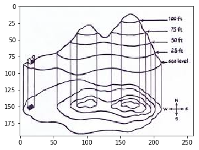

```python
#@title
import cv2
img = cv2.imread("contours.jpeg")
_=plt.imshow(img)
```

Contour and Surface Plots for $$z=x^2+y^2$$

```python
import plotly.plotly as py
import plotly.graph_objs as go

x = np.linspace(-10,10,100)
y = np.linspace(-10,10,100)
X,Y = np.meshgrid(x,y)
z = X**2 + Y**2

contours = go.Contour(
        z=z,
        x=x,
        y=y,
        contours=dict(
            coloring='lines',
        ),
    )
layout = go.Layout(
    autosize=False,
    width=500,
    height=500,
)

fig = go.Figure(data=[contours], layout=layout)
iplot(fig, filename='size-margins')
data2 = [go.Surface(z=z,x=x,y=y)]
iplot(data2)
```

[interactive chart not shown]

Surface and Contour plots for $$z=x$$

```python
#@title
import plotly.plotly as py
import plotly.graph_objs as go


x = np.linspace(-10,10,100)
y = np.linspace(-10,10,100)
X,Y = np.meshgrid(x,y)
z = X

contours = go.Contour(
        z=z,
        x=x,
        y=y,
        contours=dict(
            coloring='lines',
        ),
    )
layout = go.Layout(
    autosize=False,
    width=500,
    height=500,
)

fig = go.Figure(data=[contours], layout=layout)
iplot(fig, filename='size-margins')
data2 = [go.Surface(z=z,x=x,y=y)]
iplot(data2)
```

[interactive chart not shown]